# Ethan Harpe Lab 9 - Graphs and Trees with Python

## Lab 9: Graphs and Trees with Python

## Exercise 1: Rolling a Die

Calculate the probability of rolling a number greater than 4 on a standard six-sided die. Provide your solution using the theory of probability and compare with the simulation.

### Solution:

```python
import random

def simulate_rolling_die(trials=15600):        #TASK: Modify the number of trials and the situation
    rolls_greater_than_4 = sum([1 for _ in range(trials) if random.randint(1, 6) > 4])
    probability = rolls_greater_than_4 / trials
    return probability

print(simulate_rolling_die())
```

```
0.3292307692307692
```

## Exercise 2: Drawing a Red Card from a Deck

Calculate the probability of drawing a red card from a standard deck of 52 playing cards. Provide your solution using the theory of probability and compare with the simulation.

### Solution:

```python
import random

def simulate_drawing_red_card(trials=13450):  #TASK:  Modify the number of trials and the situation
    red_card_draws = sum([1 for _ in range(trials) if random.choice(['red', 'black']) == 'red'])
    probability = red_card_draws / trials
    return probability

print(simulate_drawing_red_card())
```

```
0.5020074349442379
```

## Exercise 3: Picking a Prime Number from 1 to 10

Calculate the probability of randomly selecting a prime number when picking a number from 1 to 10 (inclusive). Provide your solution using the theory of probability and compare with the simulation.

### Solution

```python
import random

def is_prime(n):
    if n < 2:
        return False
    for i in range(2, int(n**0.5) + 1):
        if n % i == 0:
            return False
    return True

def simulate_picking_prime(trials=11000):  #TASK: Modify the number of trials and the situation
    prime_picks = sum([1 for _ in range(trials) if is_prime(random.randint(1, 10))])
    probability = prime_picks / trials
    return probability

print(simulate_picking_prime())
```

```
0.4019090909090909
```

## Exercise 4: Even Numbers in a Lottery

In a small lottery, participants choose a number from 1 to 20. Calculate the probability of a participant choosing an even number. Provide your solution using the theory of probability and compare with the simulation.

### Solution:

```python
import random

def simulate_lottery_even_number(trials=11100):   # Modify the number of trials and the situation
    even_number_picks = sum([1 for _ in range(trials) if random.randint(1, 20) % 2 == 0])
    probability = even_number_picks / trials
    return probability

print(simulate_lottery_even_number())
```

```
0.4909009009009009
```

## Exercise 5: Undirected Graph Creation and Visualization

Create an undirected graph representing a small network of friends. The network has five people: Alice, Bob, Carol, Dave, and Eve. The friendships are as follows: Alice is friends with Bob and Carol, Bob is friends with Carol and Dave, and Carol is friends with Dave and Eve. Visualize this network, showing the sets of vertices and edges.

```python
pip install --upgrade networkx    # Execute this first
```

[output not shown]

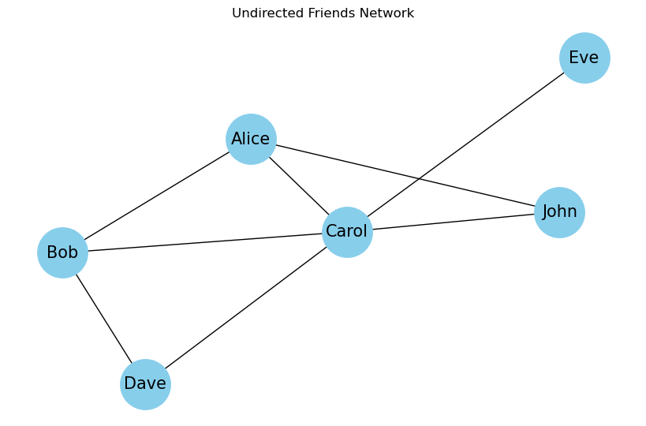

```python
import networkx as nx
import matplotlib.pyplot as plt

def create_and_plot_undirected_graph():
    # Create an undirected graph
    G = nx.Graph()

    #TASK: Add a new friend node called "John"
    G.add_node("Alice")
    G.add_node("Bob")
    G.add_node("Carol")
    G.add_node("Dave")
    G.add_node("Eve")
    G.add_node("John")



    #TASK: John is friend to "Carol" and "Alice"  # Add John edges
    edges = [("Alice", "Bob"), ("Alice", "Carol"), ("John","Carol"),("John","Alice"),("Bob", "Carol"), ("Bob", "Dave"), ("Carol", "Dave"),("Carol", "Eve")]
    G.add_edges_from(edges)

    # Draw the graph
    plt.figure(figsize=(8, 5))
    nx.draw(G, with_labels=True, node_color='skyblue', node_size=2000, edge_color='k', linewidths=2, font_size=15)
    plt.title("Undirected Friends Network")
    plt.show()

# Call the function
create_and_plot_undirected_graph()
```

## Exercise 6: Directed Graph Creation and Visualization

Create a directed graph to represent a simple social media scenario where the nodes represent users, and an edge from user A to user B means user A follows user B. The users are: Alice, Bob, Carol, Dave, and Eve. The following relationships exist: Alice follows Bob, Bob follows Carol and Eve, Carol follows Dave and Alice, and Dave follows Eve. Visualize this network, showing the sets of vertices and edges.

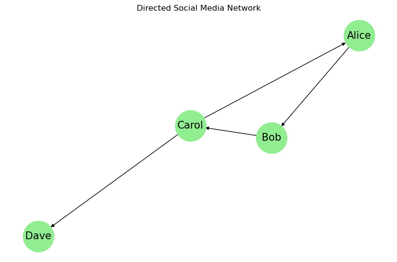

```python
import networkx as nx
import matplotlib.pyplot as plt

def create_and_plot_directed_graph():
    # Create a directed graph
    G = nx.DiGraph()

    #TASK: remove a friend node called "Eve"
    G.add_node("Alice")
    G.add_node("Bob")
    G.add_node("Carol")
    G.add_node("Dave")


    #TASK: Eve is a friend to "Bob" and "Dave"  # remove Eve edges
    edges = [("Alice", "Bob"), ("Bob", "Carol"),("Carol", "Dave"), ("Carol", "Alice")]
    G.add_edges_from(edges)

    # Draw the graph
    plt.figure(figsize=(8, 5))
    nx.draw(G, with_labels=True, node_color='lightgreen', node_size=2000, edge_color='k', linewidths=2, font_size=15, arrows=True)
    plt.title("Directed Social Media Network")
    plt.show()

# Call the function
create_and_plot_directed_graph()
```

## Exercise 7: Check if two graphs are isomorphic

Modify the examples by changing values on the adjacency_matrix and try with different graphs to verify for isomorphism.

```
True
```

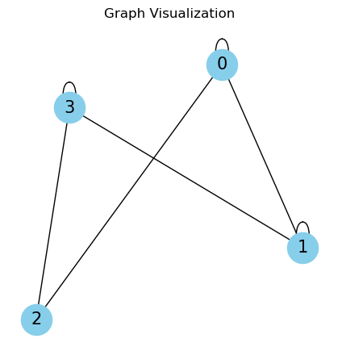

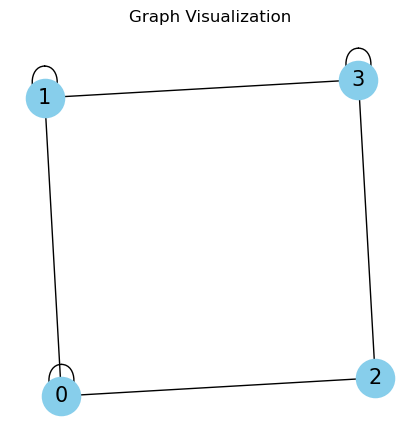

```python
# Include these libraries
import numpy as np
from itertools import permutations
import matplotlib.pyplot as plt
import networkx as nx

# Plot a graph represented by an adjacency_matrix
def plot_graph(adjacency_matrix):
    """
    Visualizes a graph given its adjacency matrix.

    Parameters:
    adjacency_matrix (np.ndarray): The adjacency matrix of the graph to visualize.
    """
    # Converts the adjacency matrix into a NetworkX graph object for visualization.
    G = nx.from_numpy_array(adjacency_matrix)

    # Sets the figure size for the plot.
    plt.figure(figsize=(4, 4))

    # Draws the graph with specified aesthetics.
    nx.draw(G, with_labels=True, node_color='skyblue', node_size=700, edge_color='k', linewidths=2, font_size=15, pos=nx.spring_layout(G))

    # Sets the title of the plot.
    plt.title('Graph Visualization')

    # Displays the plot.
    plt.show()

# Check if two graphs are isomorphic
def are_isomorphic(G1, G2):
    """
    Checks if two graphs represented by their adjacency matrices are isomorphic.

    Parameters:
    G1, G2 (np.ndarray): Adjacency matrices of the two graphs to compare.

    Returns:
    bool: True if the graphs are isomorphic, False otherwise.
    """
    # Checks if the matrices are square and of the same size, a prerequisite for isomorphism.
    if G1.shape != G2.shape or G1.shape[0] != G1.shape[1]:
        return False

    # The number of vertices in the graphs.
    n = G1.shape[0]

    # Iterates over all possible permutations of vertex labels.
    for perm in permutations(range(n)):
        # Applies the current permutation to rows and columns of G1 to simulate vertex relabeling.
        permuted_G1 = G1[np.ix_(perm, perm)]

        # Checks if the permuted version of G1 is identical to G2, indicating isomorphism.
        if np.array_equal(permuted_G1, G2):
            return True

    # Returns False if no permutation resulted in identical adjacency matrices, indicating the graphs are not isomorphic.
    return False

# Example usage
G1 = np.array([[1, 1, 1, 0],          # TASK: Modify this adjancency_matrix and check with different graphs
               [1, 1, 0, 1],
               [1, 0, 0, 1],
               [0, 0, 1, 1]])

G2 = np.array([[1, 1, 1, 0],
               [1, 1, 0, 1],
               [1, 0, 0, 1],
               [0, 0, 1, 1]])

# Checks if G1 and G2 are isomorphic and prints the result.
print(are_isomorphic(G1, G2))  # Output: True or False

# Visualizes both graphs.
plot_graph(G1)
plot_graph(G2)
```